# Introduction to SC19084

Sherry J

2020-01-03

## Overview

**SC19084** is a simple R package developed to compare the performance of two methods under circumstance of high dimensional regression. Two functions are considered, namely, *ol1* (min_beta (2 Lam)^(-1) (z - beta)^2 + p_lambda(|beta|) for L1 penalty) and *uhard* (min_beta (2 Lam)^(-1) (z - beta)^2 + lambda0 |beta| + p_lambda(|beta|) for hard-thresholding penalty).

For ol1 function, we are able to estimate coefficient vector beta for L1 penalty and the uhard function was constructed to implement the high dimensional threshold regression.

## ol1 function

To use this function, error and design matrix are required to be generated according to some rules.

```r
library(SC19084)
set.seed(123)
n<-10;p<-15
b0<-matrix(0,p,1)
b0[1:7]<-c(1,-0.5,0.7,-1.2,-0.9,0.3,0.55)
epsi <-0.01
cormat=matrix(1,p,p)
corval = 0.5
for (i in 1:(p-1)){
  for (j in (i+1):p){
    cormat[i,j]=corval^abs(i-j)
    cormat[j,i]=cormat[i,j]
 }
}
sigmat=cormat^0.5
X<-matrix(rnorm(n*p),n,p)%*%sigmat
y<-X%*%b0+0.4*matrix(rnorm(n),n,1)
Xsca <- sqrt(colSums(X^2))/sqrt(n)
X <- X/(matrix(1,n,1)%*%Xsca)
```

Then get the input parameters from what we generated above.

```r
XXmat <- n^(-1)*t(X)%*%X
cvec <- n^(-1)*t(X)%*%y
lammax = max(abs(cvec))
lammin = epsi*lammax
lamvec = lammax - (lammax - lammin)/(50 - 1)*c(0:(50 - 1))
inival<-rep(0,p)
lambda<-lamvec[50]
varset<-vector(mode="numeric")
```

Obtain coefficient vector beta for L1 penalty regression.

```r
ol1(XXmat, cvec, inival, lambda, varset, 50, 1e-4)
```

```
##  [1]  0.805862482  0.368709880  0.000000000 -1.372003342 -0.674852680
##  [6] -0.021085513  0.568264254  0.180375295  0.060483024  0.003563566
## [11]  0.225423430 -0.174781204 -0.114024592  0.000000000  0.010162554
```

## uhard function

As one step to realise ICA algorithm which is applyed to implement the high dimensional threshold regression, error and design matrix are also required to be generated.

```r
set.seed(321)
n<-10;p<-15
b0<-matrix(0,p,1)
b0[1:7]<-c(1,-0.5,0.7,-1.2,-0.9,0.3,0.55)
epsi <-0.01
cormat=matrix(1,p,p)
corval = 0.5
for (i in 1:(p-1)){
  for (j in (i+1):p){
    cormat[i,j]=corval^abs(i-j)
    cormat[j,i]=cormat[i,j]
 }
}
sigmat=cormat^0.5
X<-matrix(rnorm(n*p),n,p)%*%sigmat
y<-X%*%b0+0.4*matrix(rnorm(n),n,1)
Xsca <- sqrt(colSums(X^2))/sqrt(n)
X <- X/(matrix(1,n,1)%*%Xsca)
```

Then get the input parameters from what we generated above.

```r
XXmat <- n^(-1)*t(X)%*%X
z1 = XXmat[1, 1]
Lam<-1/z1
cvec <- n^(-1)*t(X)%*%y
z<-cvec[1]/z1
lammax = max(abs(cvec))
lammin = epsi*lammax
lamvec = lammax - (lammax - lammin)/(50 - 1)*c(0:(50 - 1))
lambda0<-lamvec[49]
lambda<-lamvec[50]
```

Obtain one number of coefficient vector beta.

```r
uhard(z, Lam, lambda0, lambda)
```

```
## [1] -0.5302706
```

Through this method, coefficient vector beta for hard-thresholding penalty regression shall be obtained.

## Question

Use knitr to produce at least 3 examples (texts, figures, tables).

## Answer

Example 1

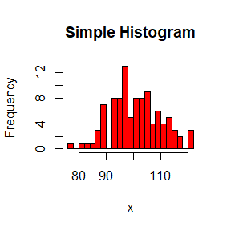

```r
#par(bg="ivory3")
set.seed(123)
x=rnorm(100,mean=100,sd=10)
hist(x,breaks=20,col=2,main="Simple Histogram")
```

A rough situation of Gaussian distribution can be observed.

Example 2

```r
A=head(freeny)
M=A[-2]
knitr::kable(M)
```

|  | y | price.index | income.level | market.potential |
| --- | --- | --- | --- | --- |
| 1962.25 | 8.79236 | 4.70997 | 5.82110 | 12.9699 |
| 1962.5 | 8.79137 | 4.70217 | 5.82558 | 12.9733 |
| 1962.75 | 8.81486 | 4.68944 | 5.83112 | 12.9774 |
| 1963 | 8.81301 | 4.68558 | 5.84046 | 12.9806 |
| 1963.25 | 8.90751 | 4.64019 | 5.85036 | 12.9831 |
| 1963.5 | 8.93673 | 4.62553 | 5.86464 | 12.9854 |

Example 3

```r
x=rbinom(50,3000,0.001)
y=rpois(50,3)
lm.cf=lm(x~y)
summary(lm.cf)$coef
```

```
##               Estimate Std. Error   t value     Pr(>|t|)
## (Intercept)  3.5467942  0.4424535  8.016197 2.081484e-10
## y           -0.1714064  0.1324450 -1.294171 2.017986e-01
```

The $R^2$ is 0.0337168

It shows the approximation between the poission distribution and the binomial distribution

## Question 3.4

The Rayleigh density [156, Ch. 18] is
$$f(x)=\frac{x}{\sigma^{2}} e^{-x^{2} /\left(2 \sigma^{2}\right)}, \quad x \geq 0, \sigma>0$$
Develop an algorithm to generate random samples from a Rayleigh(??) distribution. Generate Rayleigh(??) samples for several choices of ?? > 0 and check that the mode of the generated samples is close to the theoretical mode ??(check the histogram).

## Answer for 3.4

First, we use the inverse transform method to generate random number with the distribution in the title.

Rayleigh distribution depend on the choice of ?? so that a function is developed as below. Attention, we can also check that the mode of the generated samples is close to the theoretical mode in the function.

```r
n<-1e4
myrn<-function(sigma){
u<-runif(n)
x<-(-2*(sigma^2)*log(1-u))^(1/2)
hist(x,breaks=15, prob = TRUE,#main=expression(f(x)==x/sigma^2*exp(-(x^2)/(2*sigma^2))))
      main=paste("sigma=",sigma))
a <- seq(.001, 10, .001);y<-a/(sigma^2)*exp(-(a^2)/(2*sigma^2))
lines(a, y)
}
```

Then we generate Rayleigh samples for several choices of ?? and check that the mode of the generated samples is close to the theoretical mode by checking the histogram.

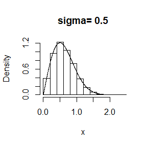

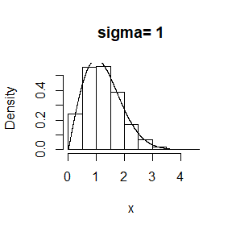

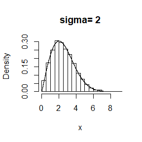

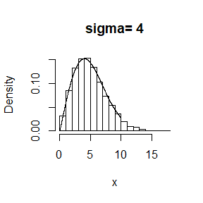

```r
#par(mfrow=c(2,2))
myrn(.5);myrn(1);myrn(2);myrn(4)
```

We can observe that the mode of the generated samples is close to the theoretical mode where $\sigma$=0.5,1,2,4.

# Wonder

Is there any other intuitive method to check that the mode of the generated samples is close to the theoretical mode ?

## Question 3.11

Generate a random sample of size 1000 from a normal location mixture. The components of the mixture have $N(0,1)$ and $N(3,1)$ distributions with mixing probabilities $p_{1}$ and $p_{2}=1-p_{1}$ . Graph the histogram of the sample with density superimposend, for $p_{1}$ = 0.75. Repeat with different values for $p_{1}$ and observe whether the empirical distribution of the mixture appears to be bimodal. Make a conjecture about the values of $p_{1}$ that produce bimodal mixtures.

## Answer for 3.11

Suppose $X_{1} \sim N(0,1)$ and $X_{2} \sim N(3,1)$ are independent.The notation $Z=p_{1} X_{1}+p_{2} X_{2}$ denotes the mixture of $X_{1}$ and $X_{2}$ .

To simulate the mixture:

1. Generate $x_{1} \sim N(0,1)$ and $x_{2} \sim N(3,1)$
2. Deliver $z=p_{1} x_{1}+p_{2} x_{2}$ for different values of $p_{1}$

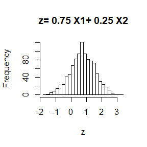

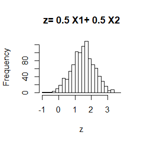

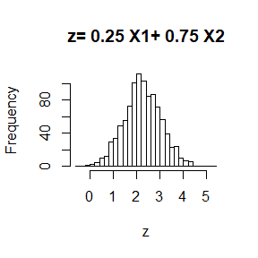

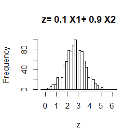

```r
n <- 1e3
x1 <- rnorm(n,0,1)
x2 <- rnorm(n,3,1)
myz<-function(r){  # function to generate different z as value of p1 changes
z <- r*x1+(1-r)*x2
hist(z,breaks=30,main=paste("z=",r,"X1+",(1-r),"X2"))
}
#par(mfrow=c(2,2))
myz(.75);myz(.5);myz(.25);myz(.1)#show histograms where p1=0,75,0.5,0.25,0.1
```

# Wonder

What are the factors influence the distance of two peaks?

## Question 3.18

Write a function to generate a random sample from a $W_{d}(\Sigma, n)$ (Wishart) distribution for $n>d+1 \geq 1$, based on Bartlett??s decomposition.

## Answer for 3.18

To generate a random sample from a $W_{d}(\Sigma, n)$ (Wishart) distribution based on Bartlett??s decomposition, we set $\Sigma$ a symmetric and positive $d \times d$ matrix as below
$$\Sigma=\left(\begin{array}{ccc}{9} & {18} & {3} \\ {18} & {40} & {16} \\ {3} & {16} & {27}\end{array}\right)$$
for a $W_{3}(\Sigma, n)$ (Wishart) distribution.

$T=\left(T_{i j}\right)$ is a lower triangular $d \times d$ random matrix with independent entries satisfying

$$\begin{array}{l}{\text { 1. } T_{i j} \stackrel{i i d}{\sim} N(0,1), i>j} \\ {\text { 2. } T_{i i} \sim \sqrt{\chi^{2}(n-i+1)}, i=1, \ldots, d}\end{array}$$

According to Bartlett??s decomposition, $A=T T^{T}$ has a $W_{3}\left(I_{3}, n\right)$ distribution. Also, we obtain the Choleski factorization $\Sigma=L L^{T}$ where $L$ is lower triangular. Finally we get $X=L A L^{T}$

On the basis of what we discussed above, a function is written to generate a random sample from a $W_{3}(\Sigma, n)$ (Wishart) distribution for any $n$ satisfying $n>d+1 \geq 1$.

```r
myW=function(n){
  sigma<-matrix(c(9,18,3,18,40,16,2,16,27),3,3)#set a three dimentional scale matrix sigma
  a<-rep(0,9);T<-matrix(a,3,3)
  T[1,1]<-sqrt(rchisq(1,n));T[2,1]<-rnorm(1);T[2,2]<-sqrt(rchisq(1,n-1))
  T[3,1]<-rnorm(1);T[3,2]<-rnorm(1);T[3,3]<-sqrt(rchisq(1,n-2))#set matrix T
  A<-T%*%t(T) #obtain matrix A
  L=matrix(c(3,6,1,0,2,5,0,0,1),3,3)#show the Choleski factorization of sigma
  X<-L%*%A%*%t(L) # obtain random sample X
  X
}
```

Now we generate a random sample from a $W_{3}(\Sigma, 30)$ (Wishart) distribution.

```r
myW(30)
```

```
##           [,1]     [,2]      [,3]
## [1,] 163.09241 336.0530  79.22149
## [2,] 336.05295 771.2830 348.45615
## [3,]  79.22149 348.4561 502.24638
```

## Question **5.1**

Compute a Monte Carlo estimate of
$$\int_{0}^{\pi / 3} \sin t d t$$

and compare your estimate with the exact value of the integral.

## Answer for **5.1**

### Basic idea

Represent the integral as the expected value of a function of a uniform random variable..

$$\theta=\int_{0}^{\pi / 3} \sin t d t=\int_{0}^{\pi / 3} \frac{1}{\pi / 3} \cdot \frac{\pi}{3} \sin t d t=\frac{\pi}{3} E(\sin X) \triangleq E(g(X)) \quad X \sim U\left(0, \frac{\pi}{3}\right)$$

1. Generate $X_{1}$ ,…,$X_{m}$, iid from Uniform$\left(0, \frac{\pi}{3}\right)$.
2. Compute $\overline{g(X)}=\frac{1}{m} \sum_{i=1}^{m} g\left(X_{i}\right)$.
3. $\hat{\theta}=(\frac{\pi}{3}-0) \overline{g(X)}$.

We can certainly handle this problem with analytic method, saying calculus. Thus we will compare the estimate with the exact value of the integral.

### Code

```r
set.seed(12345)
# for reproducible research
m <-1e5
x <-runif(m,0,pi/3)
# X with uniform distribution
g <-(pi/3)*sin(x)
est1 <-mean(g)
# Monte Carlo estimate of the integral
print(c(est1,cos(0)-cos(pi/3)))
```

```
## [1] 0.500536 0.500000
```

```r
# compare with the exact value
```

It can be observed that our estimate is correct to three decimal places.

More reliably, the standard error of $\hat{\theta}=\frac{1}{\mathrm{m}} \sum_{\mathrm{i}=1}^{\mathrm{m}} \mathrm{g}\left(\mathrm{x}_{\mathrm{i}}\right)$ and error bounds are supposed to be given.

```r
d <-sd(g)/sqrt(m)
# standard error of Monte Carlo estimate
c(est1 - 1.96 * d, est1 + 1.96 * d)
```

```
## [1] 0.4988800 0.5021921
```

```r
# 95% confidence intervals
```

## Question **5.10**

Use Monte Carlo integration with antithetic variables to estimate
$$\int_{0}^{1} \frac{e^{-x}}{1+x^{2}} d x$$
and find the approximate reduction in variance as a percentage of the variance without variance reduction.

## Answer for **5.10**

### Basic idea

1. Write a function to compute Monte Carlo estimate the same way as Q5.1.
2. Write a function to estimate the integral using Monte Carlo integration with antithetic variables.
3. Compare the two methods in terms of variance.

### Code

```r
MC <-function(n){
  x <-runif(n)
  g <-exp(-x)/(1+x^2)
  est101 <-mean(g)
  est101
}
# function of Monte Carlo estimate without antithetic variables
MC.anti<-function(n){
  u <-runif(n/2)
  v <-1-u
  g1 <-exp(-u)/(1+u^2)
  g2 <-exp(-v)/(1+v^2)
# antithetic variables
  est102 <-mean(g1+g2)/2
  est102
}
# function of Monte Carlo estimate with antithetic variables
m <-1000
set.seed(321)
MC1 <-MC2 <-numeric(m)
for (i in 1:m){
  MC1[i] <-MC(m)
  MC2[i] <-MC.anti(m/2)
}
```

A simulation under two methods, the simple Monte Carlo integration approach and the antithetic variable approach, has been done. Then we can estimate the approximate reduction in variance as follow.

```r
print((var(MC1) - var(MC2))/var(MC1))
```

```
## [1] 0.9297654
```

The antithetic variable approach achieved approximately 92.98% reduction in variance.

## Question **5.15**

Obtain the stratified importance sampling estimate in Example 5.13 and compare it with the result of Example 5.10

## Answer for **5.15**

### Basic idea

1. Devide the interval $(0,1)$ into five intervals corresponding to equal areas 1/5 under the density $f(x)$ (impartance function $f_{3}(x)$ in expample 5.10) as below.

$I_{1}=(0,0.135)$?? $I_{2}=(0.135,0.291)$?? $I_{3}=(0.291,0.477)$?? $I_{4}=(0.477,0.705)$?? $I_{5}=(0.705,1)$

2. Define
   $$g_{j}(x)=\left\{\begin{array}{cc}{\frac{e^{-x}}{1+x^{2}}} & {, x \in I_{j}} \\ {0} & {, \text { else }}\end{array}\right.$$

On the $j^{t h}$ subinterval variables are generated from the density
$$f_{j}(x)=\frac{5 e^{-x}}{1-e^{-1}} \quad x \in I_{j}$$

For each j = 1,…,5 we simulate an importance sample size r, compute the importance sampling estimator $\hat{\theta}_{j}$ of $\theta_{j}$ on the $j^{t h}$ subinterval, $\hat{\theta}^{S I}= \sum_{j=1}^{k} \hat{\theta}_{j}$

3. We also compute the importance sampling estimator with importance function $f_{3}(x)$ in example 5.10
4. Compare the results of two methods.

### Code

```r
cdf <-function(p){
  uniroot(function(x) exp(1)*(1-exp(-x))-p*(exp(1)-1),c(0,1),tol=1e-9)$root
}
# funtion to compute quantiles
x <-numeric(6)
p <-rep(.2,5)
cp <-cumsum(p)
for(i in 1:5){
  x[i+1]<-cdf(cp[i])
}
# five subintervals
m <-1e4
# number of replicates
k <-5
# number of strata
r <- m/k
# replicates per stratum
n <- 50
# number of times to repeat the estimation
T <- numeric(k)
estimates <- matrix(0,n,2)
g <- function(x){
  exp(-x - log(1+x^2)) * (x > 0) * (x < 1)
}
F <- function(x){
  exp(-x)*5/(exp(-1)-1) * (x > 0) * (x < 1)
}
for(i in 1:n) {
  v<- runif(m)
  # inverse transform method
  s <- - log(1 - v * (1 - exp(-1)))
  # random number generated from f3(x) in example 5.10
  estimates[i, 1] <- mean(g(s) / (exp(-s) / (1 - exp(-1))))
  # MC estimator with importance sampling method
for (j in 1:k){
  u<-runif(r)
  # inverse transform method
  #t<-uniroot(function(y) F(y)-F(x[j])-u,c(0,1),tol=1e-9)$root
  t<- -log(exp(-x[j])-u*(1-exp(-1))/5)
  # random number generated from f(x)
  gi<-g(t)
  fi<-exp(-t)*5/(1-exp(-1))
  Y <- gi/fi
  T[j]<-mean(Y)
  # MC estimator with importance sampling method in jth interval
}
  estimates[i, 2] <- sum(T)
  # stratified importance sampling estimate
}
```

compute mean of r simulations of both methods.

```r
 apply(estimates, 2, mean)
```

```
## [1] 0.5247500 0.5248312
```

we can observe the mean of two methods is identical to three decimal places.

```r
 apply(estimates, 2, var)
```

```
## [1] 1.208306e-06 4.572029e-08
```

the variance tells stratified importance sampling can do much better than simple importance sampling.

### Wonder

Is there any connection between the number of subinterval and the variance of our results?

#### Conjection verification

```r
xt <-numeric(11)
pt <-rep(.1,10)
cpt <-cumsum(pt)
for(i in 1:10){
  xt[i+1]<-cdf(cpt[i])
}
kt <-10
# number of strata
rt <- m/kt
# replicates per stratum
F <- numeric(kt)
test <- matrix(0,n,1)
for(i in 1:n) {
  for (j in 1:kt){
    ut<-runif(rt)
    tt<- -log(exp(-xt[j])-ut*(1-exp(-1))/10)
    git<-g(tt)
    fit<-exp(-tt)*10/(1-exp(-1))
    Yt <- git/fit
    F[j]<-mean(Yt)
  }
  # MC estimator with importance sampling method in jth interval
  test[i] <- sum(F)
  # stratified importance sampling estimate
}
```

```r
 mean(test)
```

```
## [1] 0.5248044
```

```r
 var(test)
```

```
##              [,1]
## [1,] 1.480173e-08
```

## Question **6.5**

Suppose a $95 \%$ symmetric t-interval is applied to estimate a mean, but the sample data are non-normal. Then the probability that the confidence interval covers the mean is not necessarily equal to 0.95. Use a Monte Carlo experiment to estimate the coverage probability of the t-interval for random samples of $\chi^{2}(2)$ data with sample size n = 20. Compare your t-interval results with the simulation results in Example 6.4. (The t-interval should be more robust to departures from normality than the interval for variance.)

## Answer for **6.5**

### Basic idea

If $X_{1}, \ldots, X_{n}$ is a random sample from a Normal$\left(\mu, \sigma^{2}\right)$distribution,$n \geq 2$, then
$$\frac{\bar{X}-E(\bar{X})}{\sqrt{\operatorname{Var}(\bar{X})}} \sim t(n-1)$$

Though $X \sim \chi^{2}(2)$ now, we also use the above type to estimate mean and the upper confidence limit is
$$\bar{X}+s d(\bar{X}) \cdot t_{1-\alpha}(n-1)$$

#### Solution processes

1. Set random sample size $n$ and confidence coefficient $\alpha$ (given in the item content)
2. Set simulation time $m$
3. Generate the $j^{t h}$ ($j=1, \ldots, m$) random sample $X_{1}^{(j)}, \ldots, X_{n}^{(j)}$
4. Compute $y_{j}=I\left(\bar{X} \in C_{j}\right)$ for the $j^{t h}$ sample and teh empirical confidence level $\bar{y}=\frac{1}{m} \sum_{j=1}^{m} y_{j}$

### Code

```r
rm(list=ls())
# remove variables
set.seed(123)
# for repruducible research
n<-20;alpha<-.05
CI_1<-function(a,b){
  x<-rchisq(a,2)
  UCL<-mean(x)+sqrt(var(x)/a)*qt(1-b,df=a-1)
  return(UCL)
}
# function to obtain confidence interval appling t-interval
CI_2<-function(c,d){
  y <- rnorm(c, mean=0, sd=2)
  UCL<-(c-1) * var(y) / qchisq(d, df=c-1)
  return(UCL)
}
# function to obtain confidence interval in example 6.4
```

We’ve got functions to obtain two sorts of confidence interval respectively, now let’s compare the results through some setted values.

```r
m<-1e4
# number of replication
ci_1<-replicate(m,expr=CI_1(n,alpha))
# upper confidence limit appling t-interval
ci_2<-replicate(m,expr=CI_2(n,alpha))
# upper confidence limit in example 6.4
c<-matrix(c(mean(ci_1>2),mean(ci_2>4)),1,2)
#Monte Carlo estimates of confidence level
colnames(c)<-c("ECL_1","ECL_2")
pander::pandoc.table(c)
```

| ECL_1 | ECL_2 |
| --- | --- |
| 0.8937 | 0.9503 |

We can observe that only 89.37% of the intervals contained the population mean, which is far from the 95% coverage under normality

### Wonder

Is there any method which can improve the coverage probability?

```r
set.seed(002)
n_2<-40;n_3<-80;n_4<-160
# a series of sample size
ci_11<-replicate(m,expr=CI_1(n,alpha))
ci_12<-replicate(m,expr=CI_1(n_2,alpha))
ci_13<-replicate(m,expr=CI_1(n_3,alpha))
ci_14<-replicate(m,expr=CI_1(n_4,alpha))
d<-matrix(c(mean(ci_11>2),mean(ci_12>2),mean(ci_13>2),mean(ci_14>2)),1,4)
#Monte Carlo estimates of confidence level
colnames(d)<-c("n=20","n=40","n=80","n=160")
pander::pandoc.table(d)
```

| n=20 | n=40 | n=80 | n=160 |
| --- | --- | --- | --- |
| 0.8932 | 0.9115 | 0.9203 | 0.93 |

As clearly observed, the coverage probability improves with increasing sample size.

It’s suggestive that an appropriate increase of sample size can work to improve coverage probability.

## Question **6.6**

Estimate the 0.025, 0.05, 0.95, and 0.975 quantiles of the skewness $\sqrt{b_{1}}$ under normality by a Monte Carlo experiment. Compute the standard error of the estimates from (2.14) using the normal approximation for the density (with exact variance formula). Compare the estimated quantiles with the quantiles of the large sample approximation $\sqrt{b_{1}} \approx N(0,6 / n)$.

## Answer for **6.6**

### Basic idea

The skewness $\sqrt{b_{1}}$ is
$$\sqrt{b_{1}}=\frac{\frac{1}{n} \sum_{i=1}^{n}\left(X_{i}-\bar{X}\right)^{3}}{\left(\frac{1}{n} \sum_{i=1}^{n}\left(X_{i}-\bar{X}\right)^{2}\right)^{3 / 2}}$$

If $X \sim N(0,1)$, then $\sqrt{b_{1}} \approx N(0,6 / n)$

Obviously, we can generate random numbers under normality to get samples of the skewness, then estimate quantiles of it by a Monte Carlo experiment.

#### Solution processes

1. Set random sample size $n$ and simulation time $m$
2. Generate the $j^{t h}$ ($j=1, \ldots, m$) random sample $X_{1}^{(j)}, \ldots, X_{n}^{(j)}$ under $N(0,1)$
3. Compute the skewness of sample $\sqrt{b_{1}}^{(j)}$
4. Estimate quantiles of the skewness by a Monte Carlo experiment
5. Obtain quantiles of variables under $N(0,6 / n)$
6. Compare the two sorts of quantiles
7. Compute the standard error of the estimates from (2.14) using the normal approximation for the density

### Code

```r
rm(list=ls())
# remove variables
set.seed(0321)
n<-1e3
# sample size
m<-1e4
# number of replication
sk <- function(x) {
#computes the sample skewness.
xbar <- mean(x)
m3 <- mean((x - xbar)^3)
m2 <- mean((x - xbar)^2)
return( m3 / m2^1.5 )
}
q1<-quantile(replicate(m,expr=sk(rnorm(n))),c(.025,.05,.95,.975))
# quantiles of the skewness under normality by a Monte Carlo experiment
q2<-qnorm(c(.025,.05,.95,.975),mean=0,sd=sqrt(6/n))
# quantiles of the large sample approximation
x<-matrix(c(q1,q2),2,4,byrow=T)
rownames(x)<-c("eatimate","approximation")
colnames(x)<-c("0.025","0.05","0.95","0.975")
pander::pandoc.table(x)
```

|  | 0.025 | 0.05 | 0.95 | 0.975 |
| --- | --- | --- | --- | --- |
| **eatimate** | -0.1528 | -0.1259 | 0.1268 | 0.1478 |
| **approximation** | -0.1518 | -0.1274 | 0.1274 | 0.1518 |

As is shown in the table, the estimated quantiles are close to the quantiles under $N(0,6 / n)$.

Then compute the standard error of the estimates.

```r
set.seed(007)
sd<-numeric(4)
c<-c(.025,.05,.95,.975)
for (i in 1:4){
  sd[i]<-sqrt(c[i]*(1-c[i])/(n*(dnorm(x[1,i],mean=0,sd=sqrt(6*(n-2)/((n+1)*(n+3))))^2)))
}
# standard error of the estimates
y<-matrix(sd,1,4)
rownames(y)<-"standard error"
colnames(y)<-c("0.025","0.05","0.95","0.975")
pander::pandoc.table(y)
```

|  | 0.025 | 0.05 | 0.95 | 0.975 |
| --- | --- | --- | --- | --- |
| **standard error** | 0.006765 | 0.005036 | 0.005141 | 0.005967 |

### Wonder

Decrease the sample size and see what will happen to standard error.

```r
n_2<-1e2
# decreased sample size
sd_2<-numeric(4)
for (i in 1:4){
  sd_2[i]<-sqrt(c[i]*(1-c[i])/(n_2*(dnorm(x[1,i],mean=0,sd=sqrt(6*(n_2-2)/((n_2+1)*(n_2+3))))^2)))
}
z<-matrix(sd_2,1,4)
rownames(z)<-"standard error 2"
colnames(z)<-c("0.025","0.05","0.95","0.975")
pander::pandoc.table(z)
```

|  | 0.025 | 0.05 | 0.95 | 0.975 |
| --- | --- | --- | --- | --- |
| **standard error 2** | 0.01144 | 0.01494 | 0.01497 | 0.01129 |

We can observe the standard error increases when sample size decreases, but more experiments are needed to draw a conclusion.

## Question **7.6**

Efron and Tibshirani discuss the scor (bootstrap)test score data on 88 students who took examinations in five subjects. The first two tests (mechanics, vectors) were closed book and the last three tests (algebra, analysis, statistics) were open book. Each row of the data frame is a set of scores $\left(x_{i 1}, \dots, x_{i 5}\right)$ for the $i^{t h}$ student. Use a panel display to display the scatter plots for each pair of test scores. Compare the plot with the sample correlation matrix. Obtain bootstrap estimates of the standard errors for each of the following estimates: $\hat{\rho}_{12}=\hat{\rho}(\mathrm{mec}, \mathrm{vec})$,$\hat{\rho}_{34}=\hat{\rho}(\mathrm{alg}, \mathrm{ana})$,$\hat{\rho}_{35}=\hat{\rho}(\mathrm{alg}, \mathrm{sta})$, $\hat{\rho}_{45}=\hat{\rho}(\text { ana, sta })$.

## Answer for **7.6**

### Basic idea

For using a panel display to display the scatter plots for each pair of test scores and comparing the plot with the sample correlation matrix, we found the $pairs$ function convenient to meet our requirements.

### Flowchart

1. Display the scatter plots for ten pairs of test scores with $pairs$ function.
2. Show the correlation coefficient of each pair of variables.(panel functions are taken from the $pairs$ help page)
3. Compare the scatter plots with the sample correlations.
4. Write a function that retures $b^{t h}$ replicate from $b^{t h}$ bootstrap sample, which denotes the sample correlation.
5. Using the $boot$ function to obtain bootstrap estimates of the standard errors for the four estimates respectively.

### Code

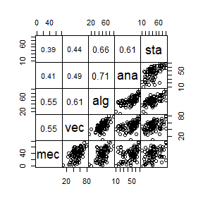

```r
rm(list=ls())
# remove variables
#library(ggplot2)
# to display scatter plots
library(bootstrap)
# to obtain data
panel.cor <- function(x, y, digits = 2, prefix = "", cex.cor, ...)
{
  usr <- par("usr"); on.exit(par(usr))
  par(usr = c(0, 1, 0, 1))
  r <- abs(cor(x, y))
  txt <- format(c(r, 0.123456789), digits = digits)[1]
  txt <- paste0(prefix, txt)
  if(missing(cex.cor)) cex.cor <- 0.8/strwidth(txt)
  text(0.5, 0.5, txt, cex = cex.cor * (1 + r) / 2)
}
# put (absolute) correlations on the upper panels with size proportional to the correlations
pairs(scor,upper.panel = panel.cor,gap=0, row1attop=FALSE)
```

As shown in the panel, the pair of scores with higher correlation has a more concentrated scatter distribution.

Then compute bootstrap estimates of the standard errors for the estimates in question.

```r
B <- 1e3
set.seed(1234)
r12 <- function(x, i) {
#want correlation of columns 1 and 2
cor(x[i,1], x[i,2])
}
r34 <- function(x, i) {
#want correlation of columns 3 and 4
cor(x[i,3], x[i,4])
}
r35 <- function(x, i) {
#want correlation of columns 3 and 5
cor(x[i,3], x[i,5])
}
r45 <- function(x, i) {
#want correlation of columns 4 and 5
cor(x[i,4], x[i,5])
}
library(boot)
# for boot function
sd_boot<-numeric(4)
#for (i in 1:4){
sd_boot[1]<-sd(boot(data=scor,statistic=r12,R=2000)$t)
sd_boot[2]<-sd(boot(data=scor,statistic=r34,R=2000)$t)
sd_boot[3]<-sd(boot(data=scor,statistic=r35,R=2000)$t)
sd_boot[4]<-sd(boot(data=scor,statistic=r45,R=2000)$t)
#}
a<-matrix(sd_boot,1,4)
colnames(a)<-c("Cor(1,2)","Cor(3,4)","Cor(3,5)","Cor(4,5)")
rownames(a)<-"sd.boot"
pander::pandoc.table(a)
```

|  | Cor(1,2) | Cor(3,4) | Cor(3,5) | Cor(4,5) |
| --- | --- | --- | --- | --- |
| **sd.boot** | 0.07733 | 0.04684 | 0.05961 | 0.06638 |

## Question **7.B**

Conduct a Monte Carlo study to estimate the coverage probabilities of the standard normal bootstrap confidence interval, the basic bootstrap confidence interval, and the percentile confidence interval. Sample from normal populations (skewness 0) and $\chi^{2}(5)$ distributions (positive skewness) and compare the empirical coverage rates for the sample skewness statistic. Find the proportion of times that the confidence intervals miss on the left, and the porportion of times that the confidence intervals miss on the right.

## Answer for **7.B**

### Basic idea

- There are several approaches to obtaining approximate confidence intervals for the sample skewness in a bootstrap. The methods include the standard normal bootstrap confidence interval, the basic bootstrap confidence interval and the bootstrap percentile confidence interval.

### Flowchart

1. Choose sample size n for the skewness.
2. Choose sample size m for bootstrap confidence interval.
3. Choose number of replicate for empirical coverage rates.
4. Run R function boot.ci{boot} implements the three bootstrap CI methods.
5. Conduct a Monte Carlo study to estimate the coverage probabilities and the proportion of times that the CI miss on the left along with on the right for the three bootstrap CI methods with normal population and $\chi^{2}(5)$ distributions respectively.

### Code

```r
rm(list=ls())
# remove variables
library(boot)
set.seed(0321)
sk_nor<-0;sk_chi<-2/sqrt(5/2)
# skewnesses with normal distribution and chi-square distribution
n <- 20
# sample size for statistic
m<-10
# sample size for confidence interval
M<-1e2
# number of replicate for empirical coverage rates
sk.boot <- function(x,i) {
  # function to compute the sample skewness statistic
  xbar <- mean(x[i,])
  m3 <- mean((x[i,] - xbar)^3)
  m2 <- mean((x[i,] - xbar)^2)
  return( m3 / m2^1.5 )
}
ci.norm_nor<-ci.norm_chi<-ci.basic_nor<-ci.basic_chi<-ci.perc_nor<-ci.perc_chi<-matrix(NA,M,2)
for(i in 1:M){
  x<-matrix(rnorm(m*n),m,n)
  # sample from normal population
  y<-matrix(rchisq(m*n,5),m,n)
  # sample from chi-square population
  de_nor <- boot(x, statistic = sk.boot, R = 1000)
  ci_nor <- boot.ci(de_nor,type=c("norm","basic","perc"))
  # bootstrap CI for normality
  de_chi <- boot(y, statistic = sk.boot, R = 1000)
  ci_chi <- boot.ci(de_chi,type=c("norm","basic","perc"))
  # bootstrap CI for chi-square
  ci.norm_nor[i,]<-ci_nor$norm[2:3]
  ci.basic_nor[i,]<-ci_nor$basic[4:5]
  ci.perc_nor[i,]<-ci_nor$percent[4:5]
  # extract three sorts of CI for normality
  ci.norm_chi[i,]<-ci_chi$norm[2:3]
  ci.basic_chi[i,]<-ci_chi$basic[4:5]
  ci.perc_chi[i,]<-ci_chi$percent[4:5]
  # extract three sorts of CI for chi-square
}
CR_nor <- c(mean(ci.norm_nor[,1]<=sk_nor & ci.norm_nor[,2]>=sk_nor),mean(ci.basic_nor[,1]<=sk_nor & ci.basic_nor[,2]>=sk_nor),mean(ci.perc_nor[,1]<=sk_nor & ci.perc_nor[,2]>=sk_nor),mean(ci.norm_nor[,1]>=sk_nor ),mean(ci.basic_nor[,1]>=sk_nor),mean(ci.perc_nor[,1]>=sk_nor),mean(ci.norm_nor[,2]<=sk_nor ),mean(ci.basic_nor[,2]<=sk_nor),mean(ci.perc_nor[,2]<=sk_nor))
# Monte Carlo estimates of CI and miss rates of both sides for normality
b<-matrix(CR_nor,3,3,byrow=T)
colnames(b)<-c("norm","basic","perc")
rownames(b)<-c("CR for normality","miss rates on the left","miss rates on the right")

CR_chi <- c(mean(ci.norm_chi[,1]<=sk_chi & ci.norm_chi[,2]>=sk_chi),mean(ci.basic_chi[,1]<=sk_chi & ci.basic_chi[,2]>=sk_chi),mean(ci.perc_chi[,1]<=sk_chi & ci.perc_chi[,2]>=sk_chi),mean(ci.norm_chi[,1]>=sk_chi ),mean(ci.basic_chi[,1]>=sk_chi),mean(ci.perc_chi[,1]>=sk_chi),mean(ci.norm_chi[,2]<=sk_chi ),mean(ci.basic_chi[,2]<=sk_chi),mean(ci.perc_chi[,2]<=sk_chi))
#Monte Carlo estimates of CI and miss rates of both sides for chi-square
c<-matrix(CR_chi,3,3,byrow=T)
colnames(c)<-c("norm","basic","perc")
rownames(c)<-c("CR for chi-square","miss rates on the left","miss rates on the right")

pander::pandoc.table(b)
```

|  | norm | basic | perc |
| --- | --- | --- | --- |
| **CR for normality** | 0.9 | 0.89 | 0.92 |
| **miss rates on the left** | 0.05 | 0.05 | 0.03 |
| **miss rates on the right** | 0.05 | 0.06 | 0.05 |

```r
pander::pandoc.table(c)
```

|  | norm | basic | perc |
| --- | --- | --- | --- |
| **CR for chi-square** | 0.79 | 0.75 | 0.75 |
| **miss rates on the left** | 0.03 | 0.06 | 0.02 |
| **miss rates on the right** | 0.18 | 0.19 | 0.23 |

We can observe that for normal populations, the coverage rates for the sample skewness are higher than for $\chi^{2}(5)$ distributions in all the three kinds of confidence interval.

At the same time, for normality the miss rates on the left are close to that on the right, while for $\chi^{2}(5)$ distributions the confidence interval always have higher miss rates on the right than on the left. Assume that’s the result of difference of distribution symmetry now let’s check our assumption.

```r
set.seed(123)
sk_exp<-2
# skewnesses with exponential distribution
ci.norm_exp<-ci.perc_exp<-ci.basic_exp<-matrix(NA,M,2)
for(i in 1:M){
  x<-matrix(rexp(m*n,2),m,n)
  # sample from exp(2) population
  de_exp <- boot(x, statistic = sk.boot, R = 1000)
  ci_exp <- boot.ci(de_exp,type=c("norm","basic","perc"))
  # bootstrap CI for exponential distribution
  ci.norm_exp[i,]<-ci_exp$norm[2:3]
  ci.basic_exp[i,]<-ci_exp$basic[4:5]
  ci.perc_exp[i,]<-ci_exp$percent[4:5]
  # extract three sorts of CI for exponential distribution
}
  CR_exp <- c(mean(ci.norm_exp[,1]<=sk_exp & ci.norm_exp[,2]>=sk_exp),mean(ci.basic_exp[,1]<=sk_exp & ci.basic_exp[,2]>=sk_exp),mean(ci.perc_exp[,1]<=sk_exp & ci.perc_exp[,2]>=sk_exp),mean(ci.norm_exp[,1]>=sk_exp ),mean(ci.basic_exp[,1]>=sk_exp),mean(ci.perc_exp[,1]>=sk_exp),mean(ci.norm_exp[,2]<=sk_exp ),mean(ci.basic_exp[,2]<=sk_exp),mean(ci.perc_exp[,2]<=sk_exp))
# Monte Carlo estimates of CI and miss rates of both sides for exponential
d<-matrix(CR_exp,3,3,byrow=T)
colnames(d)<-c("norm","basic","perc")
rownames(d)<-c("CR for exp(2)","miss rates on the left","miss rates on the right")
pander::pandoc.table(d)
```

|  | norm | basic | perc |
| --- | --- | --- | --- |
| **CR for exp(2)** | 0.68 | 0.65 | 0.64 |
| **miss rates on the left** | 0.04 | 0.08 | 0.01 |
| **miss rates on the right** | 0.28 | 0.27 | 0.35 |

For exp(2) population, we observed the same situation as $\chi^{2}(5)$ distributions in regard to the significant differentiation between miss rates on the left and on the right.

## Question **6.7**

Estimate the power of the skewness test of normality against symmetric $\operatorname{Beta}(\alpha, \alpha)$ distributions and comment on the results. Are the results different for heavy-tailed symmetric alternatives such as $t(\nu)$?

## Answer for **6.7**

### Basic idea

The skewness $\sqrt{\beta_{1}}$ of a random variable $X$ is defined by
$$\sqrt{\beta_{1}}=\frac{E\left[\left(X-\mu_{X}\right)\right]^{3}}{\sigma_{X}^{3}}$$
The sample coefficient of skewness is denoted by $\sqrt{b_{1}}$, and defined as
$$\sqrt{b_{1}}=\frac{\frac{1}{n} \sum_{i=1}^{n}\left(X_{i}-\bar{X}\right)^{3}}{\left(\frac{1}{n} \sum_{i=1}^{n}\left(X_{i}-\bar{X}\right)^{2}\right)^{3 / 2}}$$
If the distribution of $X$ is normal, then $\sqrt{b_{1}}$ is asymptotically normal with mean 0 and variance $\frac{6(n-2)}{(n+1)(n+3)}$. The hypotheses are
$$H_{0}: \sqrt{\beta_{1}}=0 ; \quad H_{1}: \sqrt{\beta_{1}} \neq 0$$
First, we estimate by simulation the power of the skewness test of normality against symmetric $\operatorname{Beta}(\alpha, \alpha)$ distributions, which is denoted by $\operatorname{Beta}(\alpha, \alpha)$.

#### Flowchart

1. Set random sample size $n$ and confidence coefficient $\alpha$
2. Set simulation time $m$
3. Generate the $j^{t h}$ ($j=1, \ldots, m$) random sample $X_{1}^{(j)}, \ldots, X_{n}^{(j)}$ under the conditions of symmetric $\operatorname{Beta}(\alpha, \alpha)$ distributions
4. Estimate the power of the skewness test of normality against symmetric $\operatorname{Beta}(\alpha, \alpha)$ distributions
5. Choose two sorts of heavy-tailed symmetric alternatives, $t(\nu)$ and $U(0,a)$, generate random sample under the conditions of the two respectively
6. Estimate the power of the skewness test of normality against the two heavy-tailed symmetric alternatives

### Code

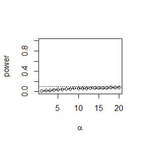

```r
rm(list=ls())
# remove variables
set.seed(123)
alpha <- .1
n <- 30
m <- 2500
a<-seq(1,20) # parameter of Beta distribution
#epsilon <- c(seq(0, .15, .01), seq(.15, 1, .05))
#N <- length(epsilon)
N <- length(a)
power <- numeric(N)
sk <- function(x) {
  # computes the sample skewness coeff.
  xbar <- mean(x)
  m3 <- mean((x - xbar)^3)
  m2 <- mean((x - xbar)^2)
  return( m3 / m2^1.5 )
}
cv <- qnorm(1-alpha/2, 0, sqrt(6*(n-2) / ((n+1)*(n+3))))
# critical value for the skewness test
for (j in 1:N) { #for each parameter of Beta distribution
e <- a[j]
stests <- numeric(m)
for (i in 1:m) { #for each replicate
  x<- rbeta(n,e,e)
  stests[i] <- as.integer(abs(sk(x)) >= cv)
}
power[j] <- mean(stests)
}
#plot power vs parameter of Beta distribution
plot(a, power, type = "b", xlab = bquote(alpha), ylim = c(0,1))
abline(h = .1, lty = 3)
se <- sqrt(power * (1-power) / m) #add standard errors
lines(a, power+se, lty = 3)
lines(a, power-se, lty = 3)
```

Then about the two heavy-tailed symmetric alternatives.

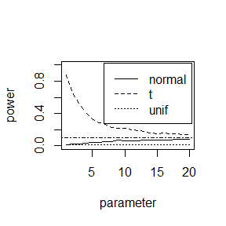

```r
power_2 <- power_3 <- numeric(N)
for (j in 1:N) { #for each parameter of t distribution
e <- a[j]
stests_2 <- numeric(m)
for (i in 1:m) { #for each replicate
  x <- rt(n,e)
  stests_2[i] <- as.integer(abs(sk(x)) >= cv)
}
power_2[j] <- mean(stests_2)
}
for (j in 1:N) { #for each parameter of uniform distribution
e <- a[j]
stests_3 <- numeric(m)
for (i in 1:m) { #for each replicate
  x <- runif(n,0,e)
  stests_3[i] <- as.integer(abs(sk(x)) >= cv)
}
power_3[j] <- mean(stests_3)
}
plot(a,power, type = "l", xlab = "parameter", ylim = c(0,1),ylab="power")
lines(a,power_2,lty=2)
lines(a,power_3,lty=3)
abline(h = alpha, lty = 4)
legend("topright",1,c("normal","t","unif"),lty=c(1,2,3),inset=.02)
```

In conclusion, $t(\nu)$ is suitable for the skewness test of normality.

### Wonder

Consider the underlying reason for the tendency of t distribution power curve.

## Question **6.A**

Use Monte Carlo simulation to investigate whether the empirical Type I error rate of the t-test is approximately equal to the nominal significance level $\alpha$, when the sampled population is non-normal. The t-test is robust to mild departures from normality. Discuss the simulation results for the cases where the sampled population is (i) $\chi^{2}(1)$, (ii) Uniform(0,2), and (iii) Exponential(rate=1). In each case, test $H_{0}: \mu=\mu_{0}$ vs $H_{0}: \mu \neq \mu_{0}$ , where $\mu_{0}$ is the mean of $\chi^{2}(1)$, Uniform(0,2), and Exponential(1), respectively.

## Answer for **6.A**

### Basic idea

Suppose that $X_{1}, \ldots, X_{20}$ is a random sample from a $N\left(\mu, \sigma^{2}\right)$ distribution. Test $H_{0}$ : ?? = 1 $H_{1}$ : ?? > 1 at $\alpha$ = 0.05. Under the null hypothesis,
$$T^{*}=\frac{\bar{X}-1}{S / \sqrt{20}} \sim t(19)$$
where t(19) denotes the Student t distribution with 19 degrees of freedom. Large values of $T^{*}$ support the alternative hypothesis.

Generate samples from non-normal distribution ,say (i) $\chi^{2}(1)$, (ii) Uniform(0,2), (iii) Exponential(rate=1), and see whether the empirical Type I error rate of the t-test is approximately equal to the nominal significance level $\alpha$.

### Code

```r
rm(list=ls())
# remove variables
set.seed(0321)
n <- 20
# sample size
m<-1e4
# number of replication
p <- matrix(0,nrow=m,ncol=3)
p.hat <- numeric(3)
alpha<-.05
mu0 <- 1

for(j in 1:m){
  x <- matrix(0,n,3)
  x[,1] <- rchisq(n,1) # random numbers from chi-square distribution
  x[,2] <- runif(n,0,2) # random numbers from uniform distribution
  x[,3] <- rexp(n,1) # random numbers from exponential distribution
  for (k in 1:3){
    ttest <- t.test(x[,k],alternative="greater",mu=mu0)
    p[j,k] <- ttest$p.value
  }
}
p.hat <- colMeans(p<alpha)
c<-matrix(p.hat,1,3)
#Monte Carlo estimates of confidence level
colnames(c)<-c("Chi-square","Uniform","Exponential")
rownames(c)<-"p.hat"
pander::pandoc.table(c)
```

|  | Chi-square | Uniform | Exponential |
| --- | --- | --- | --- |
| **p.hat** | 0.013 | 0.0498 | 0.0184 |

We can observe the empirical Type I error rate of samples generate from $\chi^{2}(1)$ and Exponential(rate=1) are far from the nominal significance level $\alpha$, which is said to be conservative, while the Uniform(0,2) sample have a empirical Type I error rate approximately equal to the nominal significance level $\alpha$.

## Discussion

If we obtain the power for two methods under a particular simulation setting with 10,000 experiments: say,0.651 for one method and 0.676 for another method. Can we say the powers are different at 0.05 level?

## Answer

### Basic idea

power$_{-}1$ denotes the empirical power for method 1 and power$_{-}2$ denotes the empirical power for the other.

letting $n_{1}=$ power $_{-} 1 * 10,000$,$n_{2}=$ power $_{-} 2 * 10,000$

First, we know that $n_{1} \sim b\left(10000, p_{1}\right)$ and $n_{2} \sim b\left(10000, p_{2}\right)$, where $p_{1}$ denotes the power for method 1 and $p_{2}$ denotes the power for method 2.

Thus, test null hypothesis **$H_{0}$ : $p_{1}$=$p_{2}$**.

Further, the two empirical power both are generated from a particular simulation setting so paired-t test is an appropriate choice to test our hypothesis.

Also, to test our hypothesis, we need more empirical powers for the two methods.

## Question **7.8**

Refer to Exercise 7.6. Efron and Tibshirani discuss the following example. The five-dimensional scores data have a $5 ?? 5$ covariance matrix $\Sigma$, with positive eigenvalues $\lambda_{1}>\cdots>\lambda_{5}$. In principal components analysis,
$$\theta=\frac{\lambda_{1}}{\sum_{j=1}^{5} \lambda_{j}}$$
measures the proportion of variance explained by the first principal component. Let $\hat{\lambda}_{1}>\cdots>\hat{\lambda}_{5}$ be the eigenvalues of $\hat{\Sigma}$, where $\hat{\Sigma}$ is the MLE of $\Sigma$. Compute the sample estimate
$$\hat{\theta}=\frac{\hat{\lambda}_{1}}{\sum_{j=1}^{5} \hat{\lambda}_{j}}$$
of $\theta$. Use jackknife to estimate the bias and standard error of $\hat{\theta}$.

## Answer for **7.8**

### Basic idea

The MLE of $\Sigma$ shall be deemed as the adjusted covariance matrix, saying $\frac{\sum_{i=1}^{n}\left(x_{i}-\bar{x}\right)\left(y_{i}-\bar{y}\right)}{n}$ instead of $\frac{\sum_{i=1}^{n}\left(x_{i}-\bar{x}\right)\left(y_{i}-\bar{y}\right)}{n-1}$.

### Flowchart

1. Obtain sample size $n$ for jackknife.
2. Compute the value of $\hat{\theta}$ using given data.
3. Obtain $\hat{\theta}_{(i)}$ ($i=1, \ldots, n$).
4. Compute the bias $E(\hat{\theta})-\theta_{0}$.
5. Compute the standard error $\widehat{\operatorname{var}}(\hat{\theta})$.

### Code

```r
rm(list=ls())
# remove variables
library(bootstrap)
# to obtain data
n<-nrow(scor)
# sample size for jackknife
theta.j<-numeric(n)
lamda.h<-eigen((n-1)*cov(scor)/n,only.values=T)$values
theta.h<-max(lamda.h)/sum(lamda.h)
# value of theta.hat
for(i in 1:n){
  y<-scor[-i,]
  x<-(n-2)*cov(y)/(n-1)
  # MLE of sigma
  lamda<-eigen(x,only.values=T)$values
  theta.j[i]<-max(lamda)/sum(lamda)
}
# theta.hat with jackknife
bias.j<-(n-1)*(mean(theta.j)-theta.h)
# bias of theta.hat with jackknife
se.j <- sqrt((n-1)*mean((theta.j-mean(theta.j))^2))
# standard error of theta.hat with jackknife
c<-matrix(round(c(original=theta.h,bias.jack=bias.j,se.jack=se.j),3),1,3)
colnames(c)<-c("original","basic.jack","se.jack")
pander::pandoc.table(c)
```

| original | basic.jack | se.jack |
| --- | --- | --- |
| 0.619 | 0.001 | 0.05 |

### Wonder

What can be done to reduce the bias and standard error of $\hat{\theta}$?

## Question **7.10**

In Example 7.18, leave-one-out (n-fold) cross validation was used to select the best fitting model. Repeat the analysis replacing the Log-Log model with a cubic polynomial model. Which of the four models is selected by the cross validation procedure? Which model is selected according to maximum adjusted $R^{2}$ ?